# Ejercicios de Ecobici

En esta notebook se llevan acabo los 3 incisos del primer ejercicio

```r
library(readr)

library(dplyr)
library(lubridate) #Fechas y horas
library(tidyr) #spread
#graficas
library(ggplot2)
library(gridExtra)
library(tseries)
#cluster
library(animation)
library(factoextra)
#test
library(funtimes)
```

**Funciones**

```r
#Prueba para tendencia en series de tiempo.

test_tend_lin<-function(dataset){
  p_values<-NULL
  ar_order<-NULL
  ar_coef<-NULL
  for(i in 1:ncol(dataset)){
    #print(i)
    dat_ts<-ts(dataset[,i]) #seleccionar serie
    aux<-notrend_test(dat_ts) #Prueba tendencia
    p_values<-c(p_values,aux$p.value) #Obtener valor p
    ar_order<-c(ar_order,aux[["estimate"]][["AR_order"]]) #Obtener AR_order
    ar_coef<-c(ar_coef,mean(aux[["estimate"]][["AR_coefficients"]])) #Obtener phi
  }
  final_v<-list(p_values,ar_order,ar_coef) #lista con todos los valores obtenidos
  final_v<- as.data.frame(final_v) #convertir a df
  names(final_v)<-c("p_values","AR_order","AR_coef")
  final_v$Estacion<- colnames(dataset) # Agregar número de estación
  return(final_v)
}
```

### Obtener datos

```r
dataset <- read_csv("csv_files/dataset.csv")
#cambiar nome de columna, fecha Arribo por facilidad de manejo
names(dataset)[names(dataset) == 'Fecha Arribo'] <-'Fecha_Arribo'
```

# 1.1 ??En qu?? horarios hay mayor afluencia y en qu?? estaciones?

### Afluencia en retiros(horarios).

```r
#Crear variable de hora de retiro como factor y variable de dia de la semana
dataset$Hora_Retiro_fac <- as.factor(hour(dataset$Hora_Retiro))
dataset$Dia_Retiro <- as.factor(wday(dataset$Fecha_Retiro, label = TRUE))

#Conteo de retiros por día, hora
e1<-dataset %>% dplyr::count(Hora_Retiro_fac,Dia_Retiro)
head(e1 %>% arrange(desc(n)),5)
```

| Hora_Retiro_fac | Dia_Retiro | n |
| --- | --- | --- |
| 18 | Wed | 16730 |
| 18 | Mon | 15707 |
| 18 | Thu | 15243 |
| 18 | Tue | 14847 |
| 8 | Tue | 14374 |

```r
#Conteo de retiros por horas
e2<- dataset %>% dplyr::count(Hora=Hora_Retiro_fac, sort = TRUE)
head(e2,5)
```

| Hora | n |
| --- | --- |
| 18 | 88774 |
| 14 | 88719 |
| 15 | 83285 |
| 13 | 79166 |
| 17 | 75785 |

```r
e2$variable<-"retiros"
```

### Afluencia en arribos(horarios).

```r
#Crear variable de hora de arribo como factor y variable de dia de la semana

dataset$HoraArribo_fac <- as.factor(hour(dataset$Hora_Arribo))
dataset$DiaArribo <- as.factor(wday(dataset$Fecha_Arribo, label = TRUE))

#Conteo de arribos por día, hora
d1<-dataset %>% count(HoraArribo_fac,DiaArribo)
head(d1 %>% arrange(desc(n)),5)
```

| HoraArribo_fac | DiaArribo | n |
| --- | --- | --- |
| 18 | Wed | 16031 |
| 18 | Mon | 14835 |
| 18 | Thu | 14769 |
| 19 | Wed | 14656 |
| 15 | Fri | 14302 |

```r
#Conteo de retiros por horas
d2<- dataset %>% count(Hora=HoraArribo_fac, sort = TRUE)
head(d2,5)
```

| Hora | n |
| --- | --- |
| 14 | 88665 |
| 18 | 86563 |
| 15 | 85583 |
| 19 | 79391 |
| 13 | 77394 |

```r
d2$variable<-"arribo"
```

## Gr??ficas de afluencia por horarios

```r
#Unir datos de afluencia
horas<-rbind(d2,e2)

#Gráfica de afluencia por horas
g4<-ggplot(horas, aes(x=as.factor(Hora), y=n, fill=variable)) +geom_bar(stat='identity', position='dodge')+theme_bw()+ggtitle(("Afluencia por hora para retiros/arribos"))

#Gráfica de afluecia de Retiros por día/Hora
f1<-ggplot(e1,aes(x=Hora_Retiro_fac, y=n, color=Dia_Retiro))+ geom_point(aes(group= Dia_Retiro)) +geom_line(aes(group= Dia_Retiro))+ggtitle("Retiros por Dia/Hora")+xlab("Hora de Retiro")+ylab("Recuento")+scale_colour_hue(labels=c('Domingo','Lunes','Martes','Miercoles','Jueves','Viernes','Sabado'))+theme_bw()

#Gráfica de afluecia de Arribos por día/Hora
g1<-ggplot(d1,aes(x=HoraArribo_fac, y=n, color=DiaArribo))+ geom_point(aes(group= DiaArribo)) +geom_line(aes(group= DiaArribo))+ggtitle("Arribos por Dia/Hora")+xlab("Hora de Arribo")+ylab("Recuento")+scale_colour_hue(labels=c('Domingo','Lunes','Martes','Miercoles','Jueves','Viernes','Sabado'))+theme_bw()
```

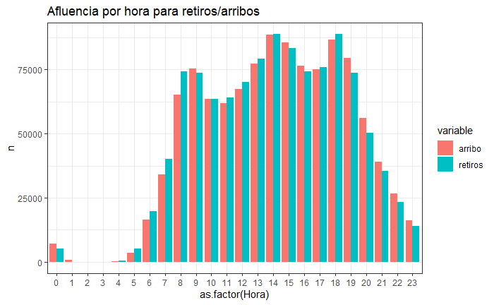

```r
g4
```

De la gr??fica podemos notar que las horas pico de Retiro son a las 18:00,14:00,15:00 y 13:00 horas mientras que para arribos son las 14:00,18:00,15:00 y 19:00 horas. Las horas pico parecen ser horarios de comida o salida de trabajo.

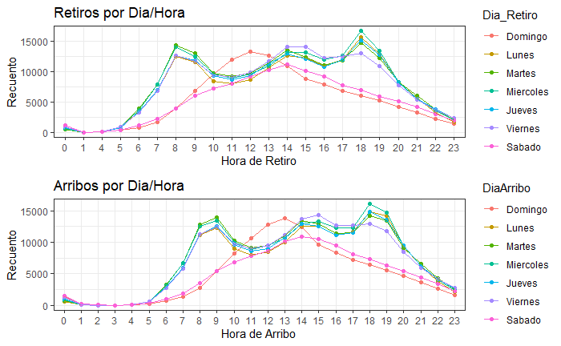

```r
grid.arrange(f1,g1)
```

Los d??as de lunes a Viernes tienen un comportamiento similar, mientras que para sabado y domingo, las horas pico de retiro son entre 12:00, 14:00 hrs mientras que para arribo son a las 13:00, 14:00 hrs

## ??En qu?? estaciones hay mayor afluencia de Retiros?

### Afluencia en estaciones para retiros

```r
#Contar usuarios en estación retiro
Retiro_count<-dplyr::count(dataset, Ciclo_Estacion_Retiro, sort = TRUE)

#seleccionamos las 10 estaciones con más Retiros
Retiro_count<-head(Retiro_count,10)$Ciclo_Estacion_Retiro

#Obtener datos de esas estaciones
Retiro_popular<-dataset %>% filter(Ciclo_Estacion_Retiro %in% Retiro_count)

#Conteos por grupos
Retiro_popular<-Retiro_popular %>% count(Ciclo_Estacion_Retiro,Hora_Retiro_fac)

#Convertir valor a factor, ordenar por estaciones con mayor afluencia
Retiro_popular$Ciclo_Estacion_Retiro<-factor(Retiro_popular$Ciclo_Estacion_Retiro, levels =Retiro_count)

#Graficar
f3<-ggplot(Retiro_popular, aes( as.factor(Ciclo_Estacion_Retiro),Hora_Retiro_fac)) +
  geom_tile(aes(fill = n), color = "blue") +
  scale_fill_gradient(low = "white", high = "steelblue") +
  ylab("Dia_Retiro") +
  xlab("Ciclo_estacion") +
  theme_bw() +
  labs(fill = "n") +ggtitle("Afluencia en estaciones de Retiro por hora",subtitle = "Estaciones ordenadas de mayor a menor afluencia")
```

### Afluencia en estaciones para arribos

```r
#Contar usuarios en estación arribo
Arribo_count<-dplyr::count(dataset, Ciclo_EstacionArribo, sort = TRUE)

#seleccionamos las 10 estaciones con más arribos
Arribo_count<-head(Arribo_count,10)$Ciclo_EstacionArribo

#Obtener datos de esas estaciones
Arribo_popular<-dataset %>% filter(Ciclo_EstacionArribo %in% Arribo_count)

#Conteos por grupos
Arribo_popular<-Arribo_popular %>% count(Ciclo_EstacionArribo,HoraArribo_fac)

#Convertir valor a factor, ordenar por estaciones con mayor afluencia
Arribo_popular$Ciclo_EstacionArribo<-factor(Arribo_popular$Ciclo_EstacionArribo, levels =Arribo_count)

#Graficar
g3<-ggplot(Arribo_popular, aes( as.factor(Ciclo_EstacionArribo),HoraArribo_fac)) +
  geom_tile(aes(fill = n), color = "blue") +
  scale_fill_gradient(low = "white", high = "steelblue") +
  ylab("DiaArribo") +
  xlab("Ciclo_estacion") +
  theme_bw() +
  labs(fill = "n") +ggtitle("Afluencia en estaciones de arribo por hora",subtitle = "Estaciones ordenadas de mayor a menor afluencia")
```

## ??En qu?? horarios hay mayor afluencia y en qu?? estaciones?

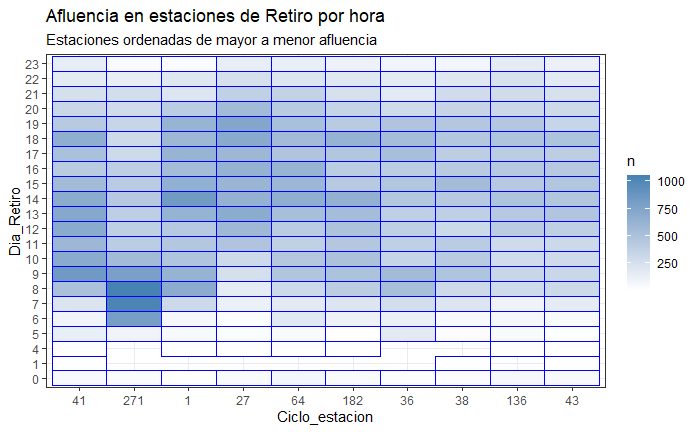

```r
f3
```

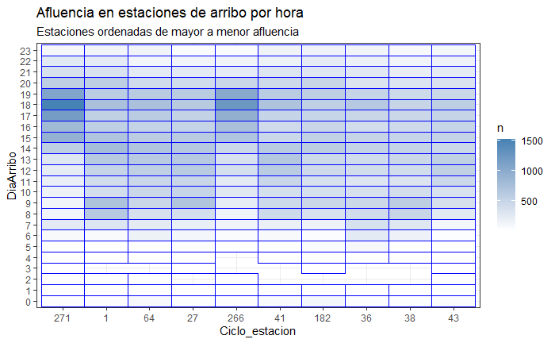

```r
g3
```

Se nota una mayor afluencia de arribo por las tardes, recordando la gr??fica de retiros, la estaci??n 271 en particular tiene muchos retiros por las ma??anas y arribos por las tardes. La mayor??a de estaciones consideradas son populares tanto en retiros como en arribos.

# 1.2. Perfiles de uso de las estaciones.

**Empezaremos por un an??lisis exploratorio**

```r
#Verificar las estaciones que tenemos
dataset%>%
    distinct(Ciclo_Estacion_Retiro) %>%
    count()
```

| n |
| --- |
| 475 |

```r
dataset%>%
    distinct(Ciclo_EstacionArribo) %>%
    count()
```

| n |
| --- |
| 475 |

```r
# De dondé retiran las bicis y a dondé llegan
bike_use_path <- dataset%>%
    group_by(Ciclo_Estacion_Retiro, Ciclo_EstacionArribo) %>%
    count() %>%
    ungroup()

#De que estaciones retiran más bicis
bike_use_retiro <- dataset%>%
    group_by(Ciclo_Estacion_Retiro) %>%
    count() %>%
    ungroup() %>%
    arrange(-n)


#A qué estaciones arriban más bicis
bike_use_arribo <- dataset%>%
    group_by(Ciclo_EstacionArribo) %>%
    count() %>%
    ungroup() %>%
    arrange(-n)
```

### Estaciones m??s y menos concurridas retiros

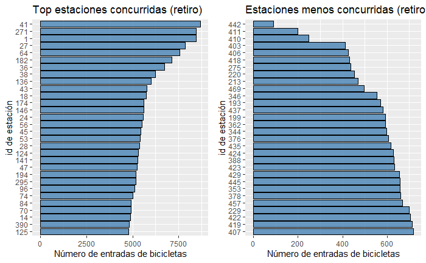

```r
bu2 <- bike_use_retiro %>%
    top_n(30) %>%
    ggplot() +
    geom_col(mapping = aes(y=as.factor(Ciclo_Estacion_Retiro) %>%
                               reorder(n),
                           x=n),
             fill = 'steelblue',
             alpha = 0.8,
             color = 'black') +
    xlab('Número de entradas de bicicletas') +
    ylab('id de estación') +
    ggtitle('Top estaciones concurridas (retiro)')
cu2 <- bike_use_retiro %>%
    top_n(-30) %>%
    ggplot() +
    geom_col(mapping = aes(y=as.factor(Ciclo_Estacion_Retiro) %>%
                               reorder(-n),
                           x=n),
             fill = 'steelblue',
             alpha = 0.8,
             color = 'black') +
    xlab('Número de entradas de bicicletas') +
    ylab('id de estación') +
    ggtitle('Estaciones menos concurridas (retiro)')
grid.arrange(bu2, cu2, ncol = 2)
```

### Estaciones m??s y menos concurridas arribos

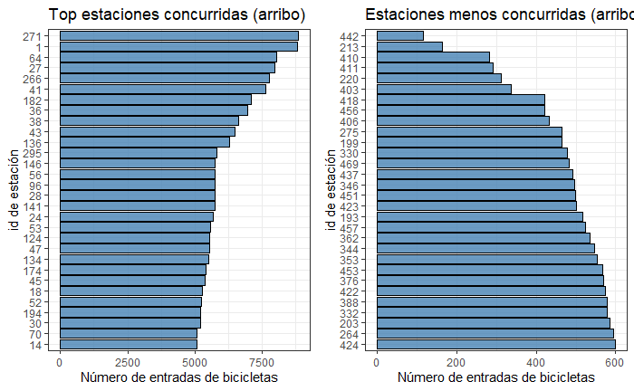

```r
#Más concurridas
bu1<-bike_use_arribo %>%
    top_n(30) %>%
    ggplot() +
    geom_col(mapping = aes(y=as.factor(Ciclo_EstacionArribo) %>%
                               reorder(n),
                           x=n),
             fill = 'steelblue',
             alpha = 0.8,
             color = 'black') +
    xlab('Número de entradas de bicicletas') +
    ylab('id de estación') +
    ggtitle('Top estaciones concurridas (arribo)')+ theme_bw()
#Menos concurridas
cu1<-bike_use_arribo %>%
    top_n(-30) %>%
    ggplot() +
    geom_col(mapping = aes(y=as.factor(Ciclo_EstacionArribo) %>%
                               reorder(-n),
                           x=n),
             fill = 'steelblue',
             alpha = 0.8,
             color = 'black') +
    xlab('Número de entradas de bicicletas') +
    ylab('id de estación') +
    ggtitle('Estaciones menos concurridas (arribo)')+ theme_bw()
grid.arrange(bu1, cu1, ncol = 2)
```

```r
#agregar variables de hora decimal
bike_tfm <-dataset %>%
    mutate(hora_arribo_decimal = hms(Hora_Arribo) %>% as.numeric() %>% round(0) / 3600,
           hora_arribo_decimal = hora_arribo_decimal %>% round(0),
           hora_retiro_decimal = hms(Hora_Retiro) %>% as.numeric() %>% round(0) / 3600,
           hora_retiro_decimal = hora_retiro_decimal %>% round(0))

bike_tfm$Genero_Usuario[is.na(bike_tfm$Genero_Usuario)] = 'NA_genero'
```

```r
#Separar arribos de retiros
bike_tfm_arribo <- bike_tfm %>%
    select(Ciclo_EstacionArribo, Genero_Usuario, Edad_Usuario, Fecha_Arribo, DiaArribo, hora_arribo_decimal)

bike_tfm_retiro <- bike_tfm %>%
    select(Ciclo_Estacion_Retiro, Genero_Usuario, Edad_Usuario, Fecha_Retiro, Dia_Retiro, hora_retiro_decimal)
```

```r
#               seccion arribos
# calculando cantidad total de arribos por estacion
bike_tfm_arribo_total_arribos <- bike_tfm_arribo %>%
    group_by(Ciclo_EstacionArribo) %>%
    summarize(total_arribos = n()) %>%
    ungroup()

# calculando la hora promedio de arribos por estacion
bike_tfm_arribo_promedio_hora <- bike_tfm_arribo %>%
    group_by(Ciclo_EstacionArribo) %>%
    summarize(promedio_hora_arribo = mean(hora_arribo_decimal)) %>%
    ungroup()

# caclculando la cantidad de arribos efectuado en fin de semana
bike_tfm_arribo_porcentake_weekend <- bike_tfm_arribo %>%
    mutate(is_weekend = if_else(DiaArribo == 'Sun' |
                                DiaArribo == 'Sat' |
                                DiaArribo == 'Fri',
                                1,
                                0)) %>%
    group_by(Ciclo_EstacionArribo) %>%
    summarize(porcentaje_arribos_weekend = sum(is_weekend) / n()) %>%
    ungroup()

bike_tfm_arribo_porcentake_weekend %>%
    ggplot() +
    geom_histogram(mapping = aes(x=porcentaje_arribos_weekend),
                   fill = 'forestgreen',
                   color = 'black',
                   alpha = 0.8)+ ggtitle("Distribuci??n de porcentaje de arribos en fin de semana")+theme_bw()
```

[output not shown]

### Preparar data para modelo

```r
library(plyr)
gen<- dataset %>% select("Ciclo_Estacion_Retiro","Genero_Usuario")


# calculando la cantidad de personas en base a genero que interactuan en cada estacion
M<-as.data.frame(table(gen)) %>% filter(Genero_Usuario == "M")
M<- M %>% select(Ciclo_Estacion_Retiro,Freq)
names(M)<- c("Estación","Genero M")

F<- as.data.frame(table(gen)) %>% filter(Genero_Usuario == "F")
F<- F %>% select(Ciclo_Estacion_Retiro,Freq)
names(F)<- c("Estación","Genero F")

#calculando la edad promedio de usuarios que interactuan en cada estacion
ed<- ddply(dataset, .(Ciclo_Estacion_Retiro), summarize,  EdadPromedio=mean(Edad_Usuario))
names(ed)<- c("Estación","Edad Promedio")

#calculando arribos en cada estacion
Ar<-as.data.frame(table(dataset$Ciclo_EstacionArribo))
names(Ar)<- c("Estación","Arribos")

#calculando retiros en cada estacion
Re<-as.data.frame(table(dataset$Ciclo_Estacion_Retiro))
names(Re)<- c("Estación","Retiros")


dataf<- Reduce(function(x, y) merge(x, y, all=TRUE), list(Re,Ar,M,F,ed))

#guardar archivo
#dataf %>% write_csv('csv_files/dataset-features-clusters.csv')

#Quitar columna de estaciones
dataf<-dataf[,-1]
dataf
```

| Retiros | Arribos | Genero M | Genero F | Edad Promedio |
| --- | --- | --- | --- | --- |
| 8448 | 8804 | 6095 | 2284 | 38.32872 |
| 4117 | 3477 | 3050 | 874 | 35.86228 |
| 1184 | 1364 | 818 | 323 | 37.11571 |
| 1205 | 1298 | 886 | 277 | 37.95187 |
| 4093 | 4109 | 3075 | 1011 | 34.52016 |
| 1277 | 1286 | 905 | 332 | 36.01723 |
| 881 | 894 | 651 | 196 | 37.28490 |
| 3406 | 3538 | 2689 | 684 | 37.35261 |
| 4207 | 4206 | 3242 | 925 | 37.65771 |
| 1484 | 1369 | 1189 | 263 | 35.97709 |

[output cut: 465 more lines]

```r
df <- scale(dataf)
head(df)
```

```
        Retiros    Arribos   Genero M   Genero F Edad Promedio
[1,]  4.1609913  4.1622489  4.2355812  4.1027892    1.63634866
[2,]  1.2188996  0.7412945  1.3337376  0.6312741   -0.01892758
[3,] -0.7735167 -0.6156562 -0.7933281 -0.7253251    0.82227512
[4,] -0.7592512 -0.6580408 -0.7285250 -0.8385802    1.38343733
[5,]  1.2025961  1.1471596  1.3575622  0.9685773   -0.91965251
[6,] -0.7103409 -0.6657471 -0.7104183 -0.7031665    0.08506214
```

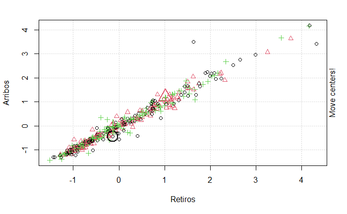

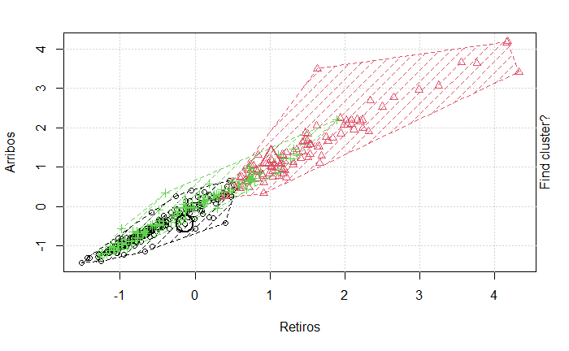

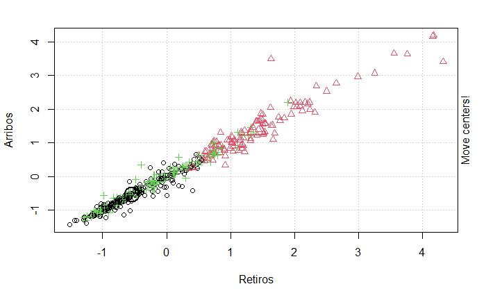

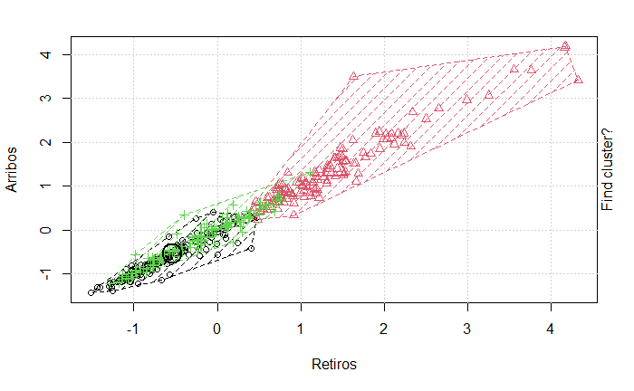

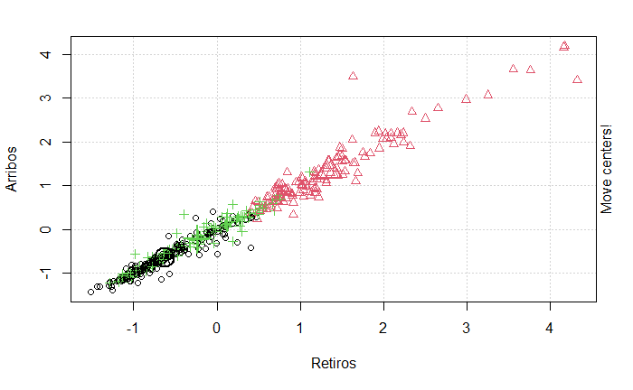

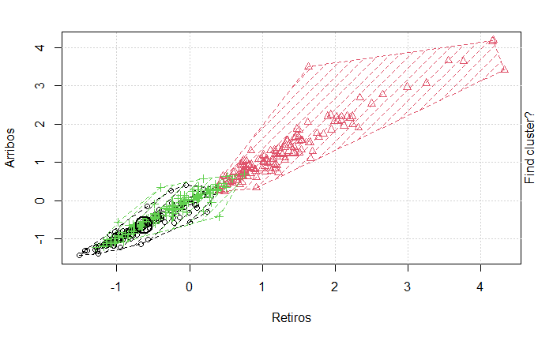

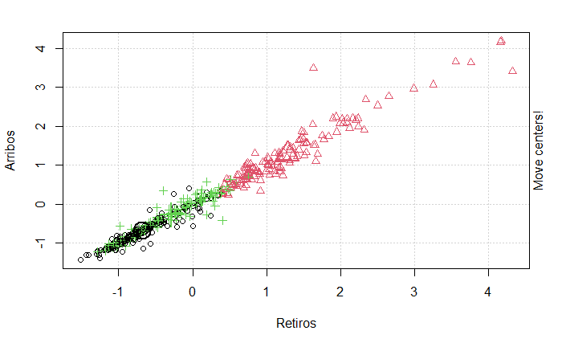

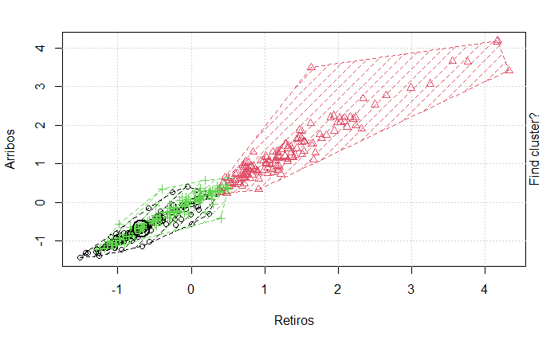

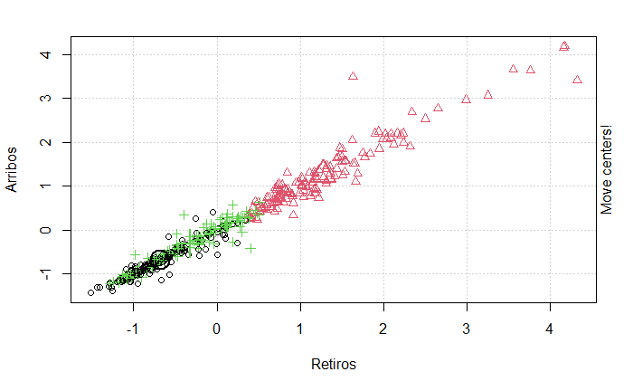

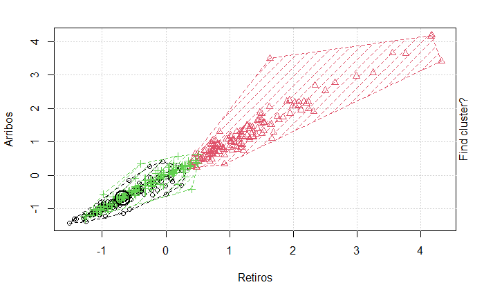

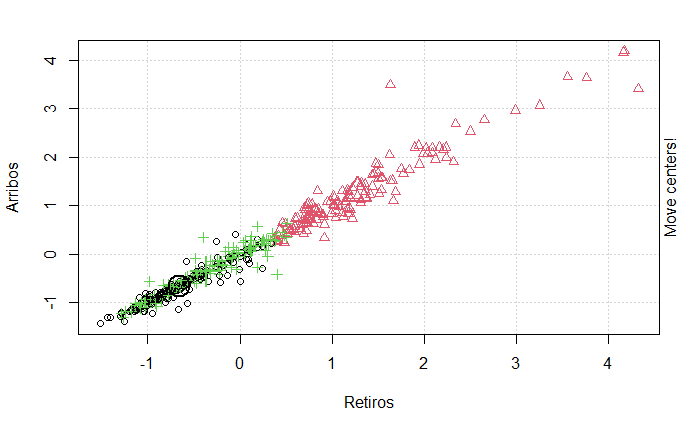

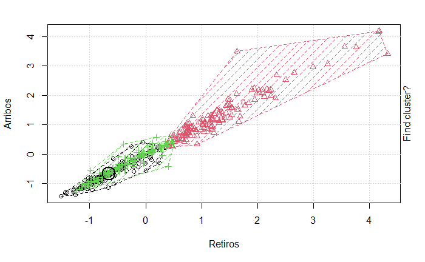

[8 more figures not shown]

```r
set.seed(2345)
library(animation)
kmeans.ani(df, 3)
```

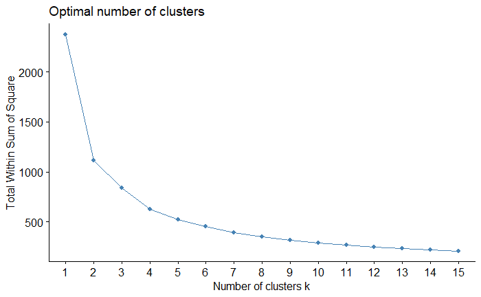

```r
fviz_nbclust(x = df, FUNcluster = kmeans, method = "wss", k.max = 15,
             diss = get_dist(df, method = "euclidean"), nstart = 50)
```

A partir de 3 clusters se comienza a estabilizar la Suma De Cuadrados Interna

Aplico k medias

```r
k3 <- kmeans(df, centers = 3, nstart = 25)
str(k3)
```

```
List of 9
 $ cluster     : int [1:475] 2 1 3 3 1 3 3 1 1 3 ...
 $ centers     : num [1:3, 1:5] 0.535 2.095 -0.716 0.513 2.114 ...
  ..- attr(*, "dimnames")=List of 2
  .. ..$ : chr [1:3] "1" "2" "3"
  .. ..$ : chr [1:5] "Retiros" "Arribos" "Genero M" "Genero F" ...
 $ totss       : num 2370
 $ withinss    : num [1:3] 256 163 418
 $ tot.withinss: num 838
 $ betweenss   : num 1532
 $ size        : int [1:3] 164 48 263
 $ iter        : int 3
 $ ifault      : int 0
 - attr(*, "class")= chr "kmeans"
```

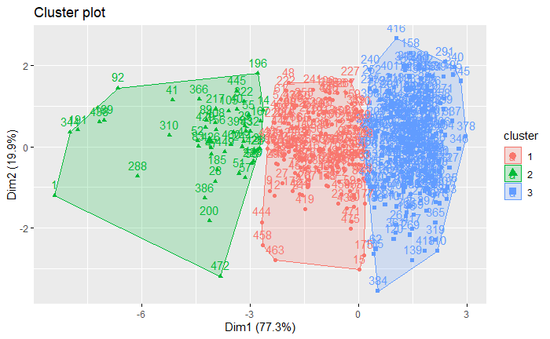

```r
fviz_cluster(k3, data = df)
```

Estos 3 perfiles ya cuenta con carateristicas diferentes de otro grupo pero similares dentro del mismo grupo. Esta segmentaci??n basicamente define perfiles en base a arribos y retiros, por lo que puede ser util para determinar la cantidad de bicicletas que deben tener en esas estaciones. Otra posible interesante agrupacion se puede hacer tomando en cuenta la variable de tiempos de uso, proporci??n de uso en fines de semana.

# 1.3. Tendencia en estaciones

**??En qu?? estaciones puedes observar una tendencia de uso a la alta?**

```r
#Vamos a considerar el uso total(arribos/retiros) de cada estación por día
#contar arribos
a1<- dataset %>% select("Ciclo_EstacionArribo","Fecha_Arribo")
a1<-as.data.frame(table(a1))
names(a1)<- c("Estacion","t","n")

#contar retiros
a2<- dataset %>% select("Ciclo_Estacion_Retiro","Fecha_Arribo")
a2<-as.data.frame(table(a2))
names(a2)<- c("Estacion","t","n")

#Unir arribos y retiros
uso_df<-merge(x=a1,y=a2,by=c("Estacion","t"),all=TRUE)
#Replace nan's with 0'
uso_df[is.na(uso_df)] <- 0
#print(sum(is.na(a)))
uso_df$n<- uso_df$n.x+uso_df$n.y
uso_df<-uso_df[,c("t","Estacion", "n")]

#regresar t a date
uso_df$t<-as.Date(uso_df$t, format= "%Y-%m-%d")

#Dejar solo datos después de Agosto, podríamos tener retiros en fechas anteriores
uso_df<-uso_df %>% filter(t>=as_date("2021-08-01") & t<=as_date("2021-10-31"))
```

Recordando que: El modelo de un proceso autorregresivo dice que en el momento $t$ el valor $Y_t$,consiste de una, $\delta$ (delta),m??s un coeficiente autorregresivo, $\phi$ (phi), por el valor del dato anterior ($Y_t$ - 1), m??s el ruido aleatorio, ??tc. La idea es tomar $\phi$, medida de cambio, para verificar que tanto aumenta o disminuye la tendencia.

Primero haremos pruebas de existencia de tendencia

```r
#Convertir cada estación en una columna
uso_df_sp<-spread(uso_df,key = Estacion,value = n)
uso_df_sp[is.na(uso_df_sp)]<-0

#H0: No existe tendecia
#H1: Tendencia lineal
#Asumiendo que las series temporales pueden estar autocorrelacionadas, aplicamos la versión sieve-bootstrap de la prueba t.

#Prueba de tendencia en series de tiempo
uso_df_ten<-test_tend_lin(uso_df_sp[,2:ncol(uso_df_sp)])

#agregar varible de estaciones
uso_df_ten$Estacion<-colnames(uso_df_sp[,2:ncol(uso_df_sp)])
```

```r
uso_df_ten_sig<-uso_df_ten %>% filter(p_values<=.05)

#Obtenemos las 10 con mayor proporci??n de cambio
tend_alta<-uso_df_ten %>% arrange(desc(AR_coef)) %>% head(10)

cat("Estaciones con tendencia a la alta:",tend_alta$Estacion)
```

[output not shown]

```r
#Obtenemos las 10 con menor proporci??n de cambio
tend_baja<-uso_df_ten%>% arrange(AR_coef) %>% head(10)

cat("Estaciones con tendencia a la baja:",tend_baja$Estacion)
```

[output not shown]

### Gr??ficas variables finales

```r
#Gr??fica de estaciones con tendencia a la alta
uso_ten_alta<-uso_df %>% filter(Estacion %in% tend_alta$Estacion)
ggplot(uso_ten_alta,aes(x=t,y=n,group=Estacion)) + geom_line()+ facet_wrap(~ Estacion)
```

[output not shown]

```r
#Gr??fica de estaciones con tendencia a la baja
uso_ten_baja<-uso_df %>% filter(Estacion %in% tend_baja$Estacion)
ggplot(uso_ten_baja,aes(x=t,y=n,group=Estacion)) + geom_line()+  facet_wrap(~ Estacion)
```

[output not shown]